# Visual patterns test analysis

# The study

### Familiarization phase

Participants see 5 stimuli repeated 8 times each. Stimuli consist of a 3x3 grid, with 5 random shapes (circle,triangle,square) placed randomly (any 9 cells) with random color (red,blue,yellow,green,orange,purple).

### Study phase

Participants see the 5 familiar stimuli 5 times each (25) and 50 novel stimuli. They have to judge if the current stimulus is one of the familiars. The novels differ to a differing degree from the familiars: there is 5x2 (two for each familiar) that is wholly different (diffarr). 5x2 that has the same placement of random shapes (sarr), 5x2 same arrangement and shapes (sarrsha), 5x2 same arrangement and colors (sarrcol) 5x2 same arrangement, shapes and colors (colors are randomized, thus, these are not the same as the familiars - sarrshacol).

### Test phase

Participants see the novels from the study phase and 50 new stimuli (sarr - 10, sarrsha - 10, etc.). Participants have to signal if they have already seen the current stimulus or it is wholly new. They had the option to signal “maybe”, but were asked to do this in moderation (maybe resp <= 20). These responses have been added to correct responses.

# Participants

The online task has been started by a total of 69 participants.

We excluded a total of 9 participants due to irregular data (incomplete runs, several runs).

We also excluded some (1) participants as they missed more than 66.3065823 trials (mean + 2*sd of misses by participant).

We also excluded 4 participants as they overused “maybe” responses in the test phase (more than 25).

The sample had a mean(±sd) age of 23.025641 ± 4.8530358.

## Study phase:

During the study phase, the participants see familiar and novel items.

The original sample of 41 participants produced a mean (±sd) recognition rate of 0.7121951 ± 0.1012796 for familiar pictures.

The sample performed above chance levels, as a one sample t-test showed (t(40)=13.4154508, p = 2.154104610^{-16}, Cohen’s d = 2.0951414, 95% CI:1.3095359 - 2.880747).

We use an ANOVA to see if there is a difference in correct rejection for the different novels.

```
## Anova Table (Type 3 tests)
##
## Response: crrate
##   Effect           df  MSE         F  ges p.value
## 1   type 3.52, 140.77 0.02 16.07 *** .125   <.001
## ---
## Signif. codes:  0 '***' 0.001 '**' 0.01 '*' 0.05 '+' 0.1 ' ' 1
##
## Sphericity correction method: GG
```

```
##  contrast             estimate     SE  df t.ratio p.value
##  diffarr - sarr        0.13171 0.0288 160  4.569  0.0001
##  diffarr - sarrcol     0.12439 0.0288 160  4.316  0.0003
##  diffarr - sarrsha     0.22927 0.0288 160  7.954  <.0001
##  diffarr - sarrshacol  0.10488 0.0288 160  3.639  0.0034
##  sarr - sarrcol       -0.00732 0.0288 160 -0.254  0.9991
##  sarr - sarrsha        0.09756 0.0288 160  3.385  0.0079
##  sarr - sarrshacol    -0.02683 0.0288 160 -0.931  0.8846
##  sarrcol - sarrsha     0.10488 0.0288 160  3.639  0.0034
##  sarrcol - sarrshacol -0.01951 0.0288 160 -0.677  0.9612
##  sarrsha - sarrshacol -0.12439 0.0288 160 -4.316  0.0003
##
## P value adjustment: tukey method for comparing a family of 5 estimates
```

```
##  contrast  estimate     SE  df t.ratio p.value
##  linear     -0.3073 0.0645 160 -4.768  <.0001
##  quadratic   0.4000 0.0763 160  5.245  <.0001
##  cubic       0.0902 0.0645 160  1.400  0.1634
##  quartic     0.5927 0.1705 160  3.476  0.0007
```

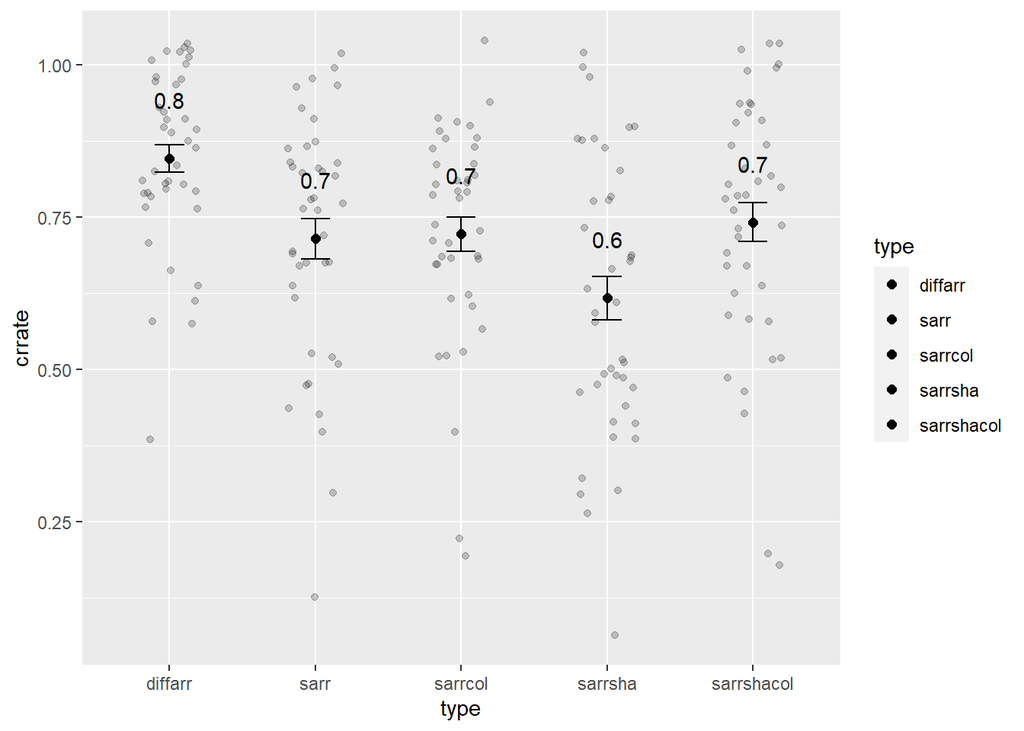

## Test phase:

```
## [1] "A t-test to compare the number of old responses btwn old and new stim"
```

```
##
##  Paired t-test
##
## data:  a and b
## t = 6.6558, df = 40, p-value = 5.672e-08
## alternative hypothesis: true difference in means is not equal to 0
## 95 percent confidence interval:
##  4.025194 7.535781
## sample estimates:
## mean of the differences
##                5.780488
```

```
##
## Cohen's d
##
## d estimate: 0.7713524 (medium)
## 95 percent confidence interval:
##     lower     upper
## 0.5086435 1.0340613
```

```
##
##  Shapiro-Wilk normality test
##
## data:  d
## W = 0.98227, p-value = 0.761
```

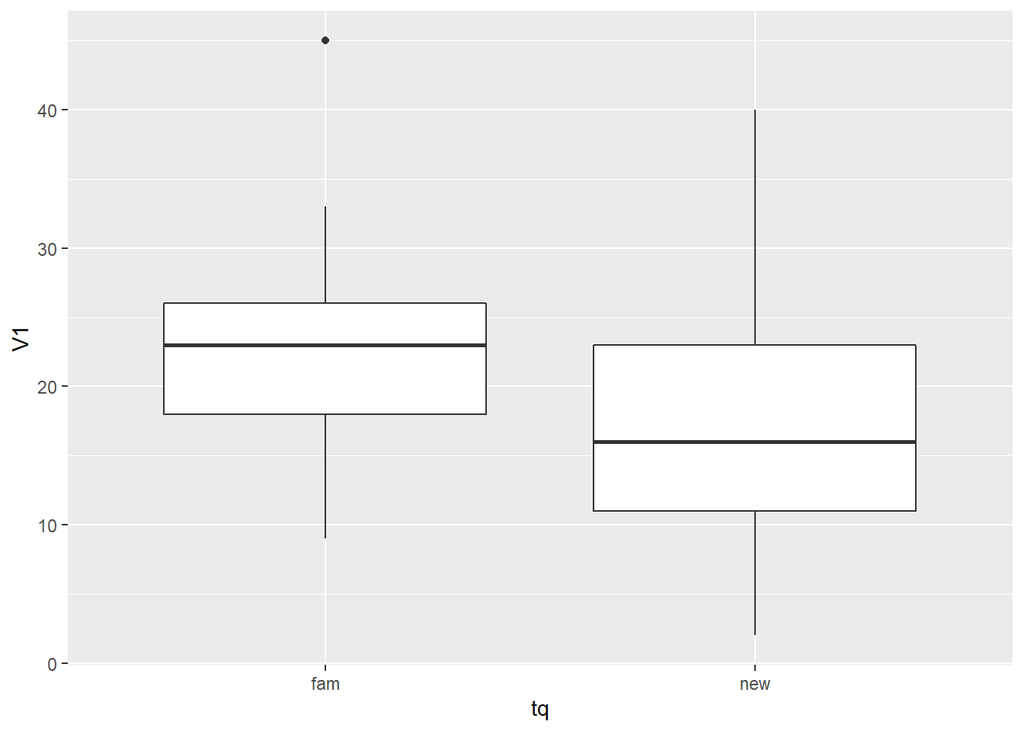

```
## [1] "ANOVA for 'Already Seen' responses"
```

```
## Anova Table (Type 3 tests)
##
## Response: rowCount
##    Effect           df  MSE         F  ges p.value
## 1    type 2.54, 101.51 6.76 27.14 *** .199   <.001
## 2      tq        1, 40 3.09 44.30 *** .068   <.001
## 3 type:tq 3.56, 142.40 2.14  6.67 *** .026   <.001
## ---
## Signif. codes:  0 '***' 0.001 '**' 0.01 '*' 0.05 '+' 0.1 ' ' 1
##
## Sphericity correction method: GG
```

```
##  contrast                        estimate    SE  df t.ratio p.value
##  diffarr,fam - sarr,fam           -0.8780 0.389 279 -2.259  0.4193
##  diffarr,fam - sarrcol,fam        -1.3415 0.389 279 -3.451  0.0223
##  diffarr,fam - sarrsha,fam        -2.7805 0.389 279 -7.153  <.0001
##  diffarr,fam - sarrshacol,fam     -1.7805 0.389 279 -4.581  0.0003
##  diffarr,fam - diffarr,new         1.9024 0.323 191  5.884  <.0001
##  diffarr,fam - sarr,new            0.6341 0.403 276  1.572  0.8604
##  diffarr,fam - sarrcol,new        -0.8537 0.403 276 -2.117  0.5174
##  diffarr,fam - sarrsha,new        -1.0488 0.403 276 -2.600  0.2225
##  diffarr,fam - sarrshacol,new     -1.6341 0.403 276 -4.052  0.0026
##  sarr,fam - sarrcol,fam           -0.4634 0.389 279 -1.192  0.9731
##  sarr,fam - sarrsha,fam           -1.9024 0.389 279 -4.894  0.0001
##  sarr,fam - sarrshacol,fam        -0.9024 0.389 279 -2.322  0.3783
##  sarr,fam - diffarr,new            2.7805 0.403 276  6.894  <.0001
##  sarr,fam - sarr,new               1.5122 0.323 191  4.677  0.0002
##  sarr,fam - sarrcol,new            0.0244 0.403 276  0.060  1.0000
##  sarr,fam - sarrsha,new           -0.1707 0.403 276 -0.423  1.0000
##  sarr,fam - sarrshacol,new        -0.7561 0.403 276 -1.875  0.6861
##  sarrcol,fam - sarrsha,fam        -1.4390 0.389 279 -3.702  0.0096
##  sarrcol,fam - sarrshacol,fam     -0.4390 0.389 279 -1.129  0.9813
##  sarrcol,fam - diffarr,new         3.2439 0.403 276  8.043  <.0001
##  sarrcol,fam - sarr,new            1.9756 0.403 276  4.898  0.0001
##  sarrcol,fam - sarrcol,new         0.4878 0.323 191  1.509  0.8873
##  sarrcol,fam - sarrsha,new         0.2927 0.403 276  0.726  0.9993
##  sarrcol,fam - sarrshacol,new     -0.2927 0.403 276 -0.726  0.9993
##  sarrsha,fam - sarrshacol,fam      1.0000 0.389 279  2.573  0.2357
##  sarrsha,fam - diffarr,new         4.6829 0.403 276 11.611  <.0001
##  sarrsha,fam - sarr,new            3.4146 0.403 276  8.466  <.0001
##  sarrsha,fam - sarrcol,new         1.9268 0.403 276  4.777  0.0001
##  sarrsha,fam - sarrsha,new         1.7317 0.323 191  5.356  <.0001
##  sarrsha,fam - sarrshacol,new      1.1463 0.403 276  2.842  0.1277
##  sarrshacol,fam - diffarr,new      3.6829 0.403 276  9.132  <.0001
##  sarrshacol,fam - sarr,new         2.4146 0.403 276  5.987  <.0001
##  sarrshacol,fam - sarrcol,new      0.9268 0.403 276  2.298  0.3936
##  sarrshacol,fam - sarrsha,new      0.7317 0.403 276  1.814  0.7257
##  sarrshacol,fam - sarrshacol,new   0.1463 0.323 191  0.453  1.0000
##  diffarr,new - sarr,new           -1.2683 0.389 279 -3.263  0.0402
##  diffarr,new - sarrcol,new        -2.7561 0.389 279 -7.091  <.0001
##  diffarr,new - sarrsha,new        -2.9512 0.389 279 -7.593  <.0001
##  diffarr,new - sarrshacol,new     -3.5366 0.389 279 -9.099  <.0001
##  sarr,new - sarrcol,new           -1.4878 0.389 279 -3.828  0.0061
##  sarr,new - sarrsha,new           -1.6829 0.389 279 -4.330  0.0009
##  sarr,new - sarrshacol,new        -2.2683 0.389 279 -5.836  <.0001
##  sarrcol,new - sarrsha,new        -0.1951 0.389 279 -0.502  1.0000
##  sarrcol,new - sarrshacol,new     -0.7805 0.389 279 -2.008  0.5942
##  sarrsha,new - sarrshacol,new     -0.5854 0.389 279 -1.506  0.8890
##
## P value adjustment: tukey method for comparing a family of 10 estimates
```

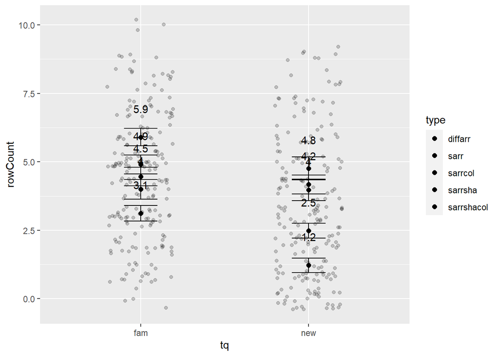

```
## [1] "ANOVA for 'Never Seen' responses"
```

```
## Anova Table (Type 3 tests)
##
## Response: rowCount
##    Effect           df  MSE         F  ges p.value
## 1    type 2.80, 112.19 5.42 32.41 *** .199   <.001
## 2      tq        1, 40 2.43 42.55 *** .050   <.001
## 3 type:tq 3.44, 137.41 2.23   4.13 ** .016    .005
## ---
## Signif. codes:  0 '***' 0.001 '**' 0.01 '*' 0.05 '+' 0.1 ' ' 1
##
## Sphericity correction method: GG
```

```
##  contrast                        estimate    SE  df t.ratio p.value
##  diffarr,fam - sarr,fam             0.878 0.373 289   2.351 0.3595
##  diffarr,fam - sarrcol,fam          1.415 0.373 289   3.788 0.0070
##  diffarr,fam - sarrsha,fam          2.561 0.373 289   6.858 <.0001
##  diffarr,fam - sarrshacol,fam       2.098 0.373 289   5.617 <.0001
##  diffarr,fam - diffarr,new         -1.805 0.314 198  -5.751 <.0001
##  diffarr,fam - sarr,new            -0.439 0.380 287  -1.155 0.9783
##  diffarr,fam - sarrcol,new          1.049 0.380 287   2.759 0.1558
##  diffarr,fam - sarrsha,new          1.415 0.380 287   3.722 0.0089
##  diffarr,fam - sarrshacol,new       1.707 0.380 287   4.492 0.0004
##  sarr,fam - sarrcol,fam             0.537 0.373 289   1.437 0.9146
##  sarr,fam - sarrsha,fam             1.683 0.373 289   4.507 0.0004
##  sarr,fam - sarrshacol,fam          1.220 0.373 289   3.266 0.0398
##  sarr,fam - diffarr,new            -2.683 0.380 287  -7.058 <.0001
##  sarr,fam - sarr,new               -1.317 0.314 198  -4.197 0.0016
##  sarr,fam - sarrcol,new             0.171 0.380 287   0.449 1.0000
##  sarr,fam - sarrsha,new             0.537 0.380 287   1.412 0.9229
##  sarr,fam - sarrshacol,new          0.829 0.380 287   2.182 0.4719
##  sarrcol,fam - sarrsha,fam          1.146 0.373 289   3.070 0.0702
##  sarrcol,fam - sarrshacol,fam       0.683 0.373 289   1.829 0.7164
##  sarrcol,fam - diffarr,new         -3.220 0.380 287  -8.470 <.0001
##  sarrcol,fam - sarr,new            -1.854 0.380 287  -4.877 0.0001
##  sarrcol,fam - sarrcol,new         -0.366 0.314 198  -1.166 0.9766
##  sarrcol,fam - sarrsha,new          0.000 0.380 287   0.000 1.0000
##  sarrcol,fam - sarrshacol,new       0.293 0.380 287   0.770 0.9989
##  sarrsha,fam - sarrshacol,fam      -0.463 0.373 289  -1.241 0.9651
##  sarrsha,fam - diffarr,new         -4.366 0.380 287 -11.486 <.0001
##  sarrsha,fam - sarr,new            -3.000 0.380 287  -7.892 <.0001
##  sarrsha,fam - sarrcol,new         -1.512 0.380 287  -3.978 0.0035
##  sarrsha,fam - sarrsha,new         -1.146 0.314 198  -3.653 0.0120
##  sarrsha,fam - sarrshacol,new      -0.854 0.380 287  -2.246 0.4281
##  sarrshacol,fam - diffarr,new      -3.902 0.380 287 -10.266 <.0001
##  sarrshacol,fam - sarr,new         -2.537 0.380 287  -6.673 <.0001
##  sarrshacol,fam - sarrcol,new      -1.049 0.380 287  -2.759 0.1558
##  sarrshacol,fam - sarrsha,new      -0.683 0.380 287  -1.797 0.7369
##  sarrshacol,fam - sarrshacol,new   -0.390 0.314 198  -1.243 0.9643
##  diffarr,new - sarr,new             1.366 0.373 289   3.658 0.0111
##  diffarr,new - sarrcol,new          2.854 0.373 289   7.642 <.0001
##  diffarr,new - sarrsha,new          3.220 0.373 289   8.621 <.0001
##  diffarr,new - sarrshacol,new       3.512 0.373 289   9.405 <.0001
##  sarr,new - sarrcol,new             1.488 0.373 289   3.984 0.0034
##  sarr,new - sarrsha,new             1.854 0.373 289   4.964 0.0001
##  sarr,new - sarrshacol,new          2.146 0.373 289   5.748 <.0001
##  sarrcol,new - sarrsha,new          0.366 0.373 289   0.980 0.9932
##  sarrcol,new - sarrshacol,new       0.659 0.373 289   1.763 0.7575
##  sarrsha,new - sarrshacol,new       0.293 0.373 289   0.784 0.9988
##
## P value adjustment: tukey method for comparing a family of 10 estimates
```

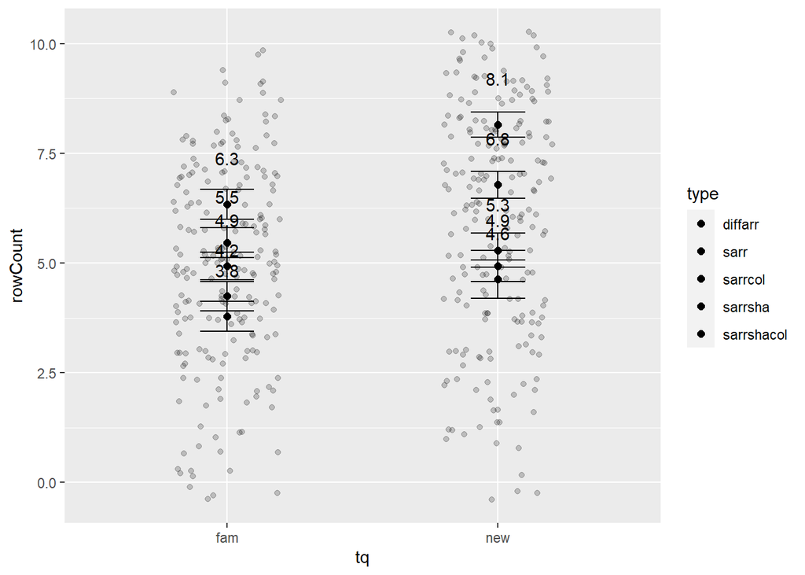

```
## [1] "This plot shows the responses to familiars. left = seen; down = may have seen; right = not seen"
```

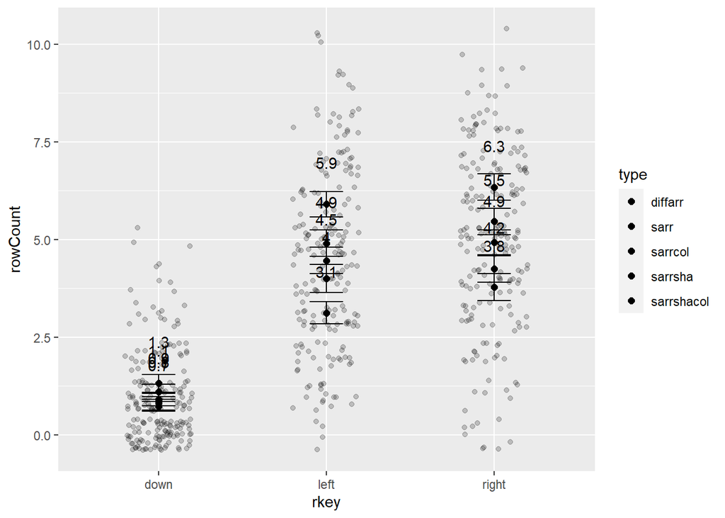

```
## [1] "This plot shows the responses to novels. left = seen; down = may have seen; right = not seen"
```

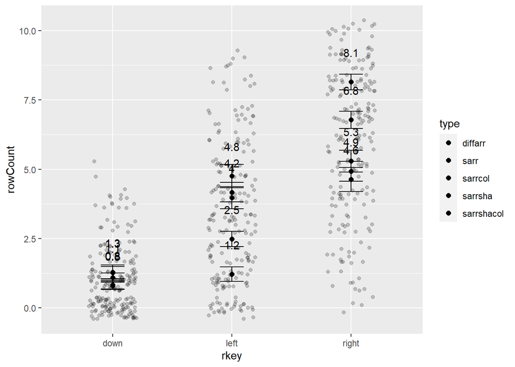

```
## [1] "ANOVA with correct recognition minus false alarm by category"
```

```
## Anova Table (Type 3 tests)
##
## Response: ccr
##   Effect           df  MSE        F  ges p.value
## 1   type 3.55, 156.02 4.30 5.95 *** .077   <.001
## ---
## Signif. codes:  0 '***' 0.001 '**' 0.01 '*' 0.05 '+' 0.1 ' ' 1
##
## Sphericity correction method: GG
```

```
##  contrast             estimate    SE  df t.ratio p.value
##  diffarr - sarr         0.4000 0.411 176  0.972  0.8673
##  diffarr - sarrcol      1.2444 0.411 176  3.025  0.0236
##  diffarr - sarrsha      0.0889 0.411 176  0.216  0.9995
##  diffarr - sarrshacol   1.5778 0.411 176  3.835  0.0016
##  sarr - sarrcol         0.8444 0.411 176  2.053  0.2456
##  sarr - sarrsha        -0.3111 0.411 176 -0.756  0.9426
##  sarr - sarrshacol      1.1778 0.411 176  2.863  0.0375
##  sarrcol - sarrsha     -1.1556 0.411 176 -2.809  0.0434
##  sarrcol - sarrshacol   0.3333 0.411 176  0.810  0.9272
##  sarrsha - sarrshacol   1.4889 0.411 176  3.619  0.0035
##
## P value adjustment: tukey method for comparing a family of 5 estimates
```

```
##  contrast  estimate   SE  df t.ratio p.value
##  linear      -2.844 0.92 176 -3.092  0.0023
##  quadratic   -0.178 1.09 176 -0.163  0.8704
##  cubic       -2.200 0.92 176 -2.392  0.0178
##  quartic     -7.089 2.43 176 -2.913  0.0040
```

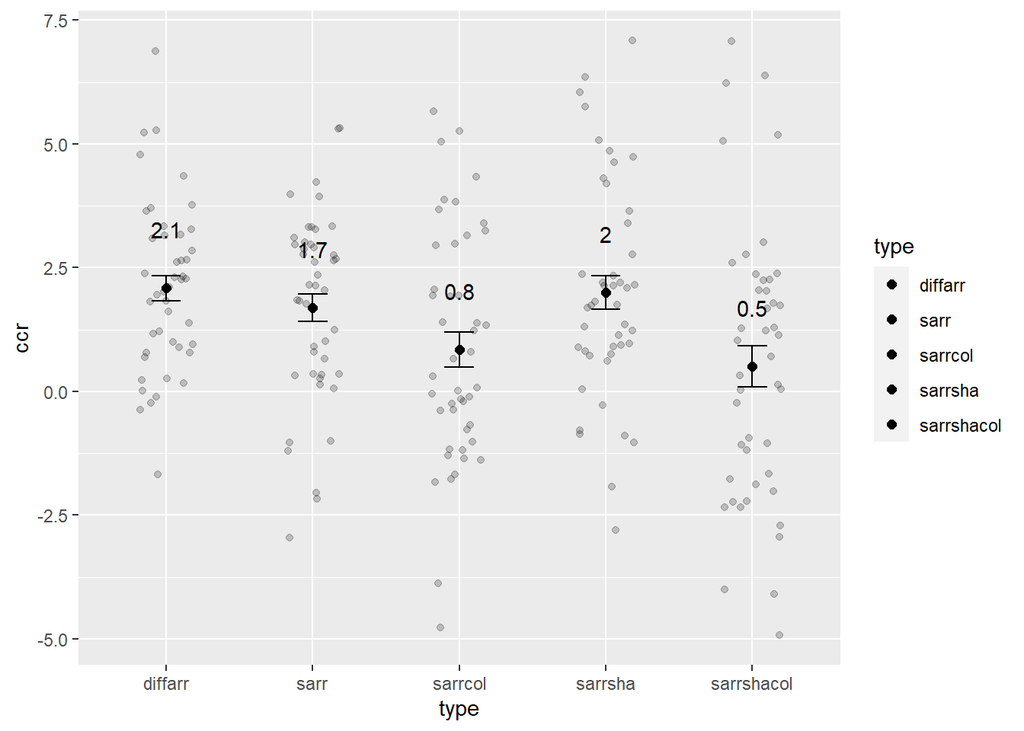

```
## [1] "ANOVA with correct rejection minus false alarm by category"
```

```
## Anova Table (Type 3 tests)
##
## Response: ccr
##   Effect           df  MSE      F  ges p.value
## 1   type 3.45, 151.81 4.37 3.46 * .047    .014
## ---
## Signif. codes:  0 '***' 0.001 '**' 0.01 '*' 0.05 '+' 0.1 ' ' 1
##
## Sphericity correction method: GG
```

```
##  contrast             estimate    SE  df t.ratio p.value
##  diffarr - sarr         0.4444 0.409 176  1.086  0.8135
##  diffarr - sarrcol      1.2222 0.409 176  2.987  0.0264
##  diffarr - sarrsha      0.6000 0.409 176  1.466  0.5857
##  diffarr - sarrshacol   1.2667 0.409 176  3.096  0.0192
##  sarr - sarrcol         0.7778 0.409 176  1.901  0.3208
##  sarr - sarrsha         0.1556 0.409 176  0.380  0.9955
##  sarr - sarrshacol      0.8222 0.409 176  2.009  0.2658
##  sarrcol - sarrsha     -0.6222 0.409 176 -1.521  0.5505
##  sarrcol - sarrshacol   0.0444 0.409 176  0.109  1.0000
##  sarrsha - sarrshacol   0.6667 0.409 176  1.629  0.4808
##
## P value adjustment: tukey method for comparing a family of 5 estimates
```

```
##  contrast  estimate    SE  df t.ratio p.value
##  linear      -2.689 0.915 176 -2.939  0.0037
##  quadratic    0.956 1.083 176  0.883  0.3786
##  cubic       -0.956 0.915 176 -1.044  0.2978
##  quartic     -4.422 2.421 176 -1.827  0.0694
```

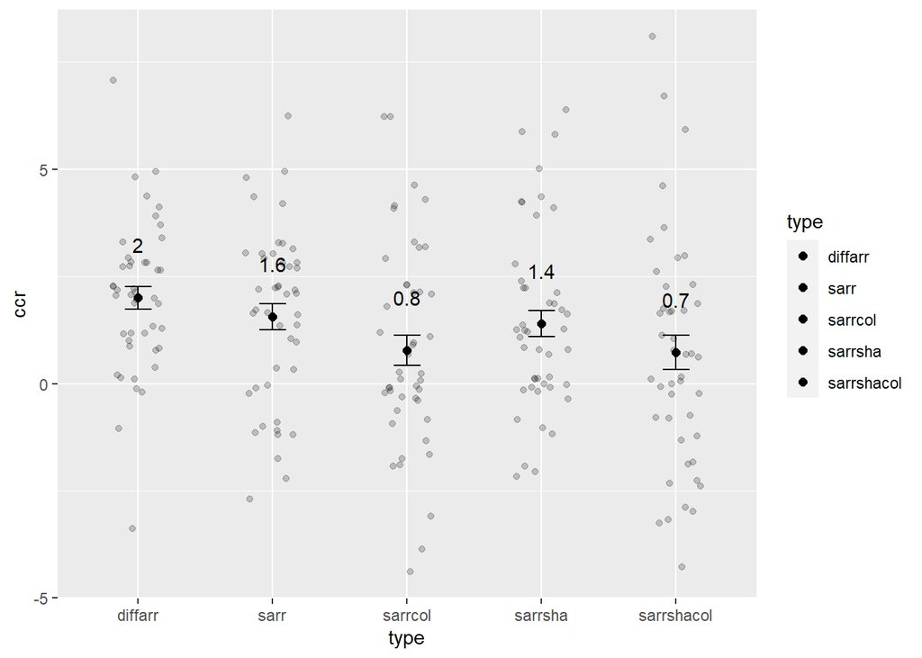

```
## [1] "ANOVA with corrected differentiation score by category ((crecog-fa)+(creject-fa))"
```

```
## Anova Table (Type 3 tests)
##
## Response: occr
##   Effect           df   MSE       F  ges p.value
## 1   type 3.48, 153.13 16.39 4.73 ** .062    .002
## ---
## Signif. codes:  0 '***' 0.001 '**' 0.01 '*' 0.05 '+' 0.1 ' ' 1
##
## Sphericity correction method: GG
```

```
##  contrast             estimate    SE  df t.ratio p.value
##  diffarr - sarr          0.844 0.796 176  1.061  0.8263
##  diffarr - sarrcol       2.467 0.796 176  3.098  0.0190
##  diffarr - sarrsha       0.689 0.796 176  0.865  0.9092
##  diffarr - sarrshacol    2.844 0.796 176  3.573  0.0041
##  sarr - sarrcol          1.622 0.796 176  2.037  0.2526
##  sarr - sarrsha         -0.156 0.796 176 -0.195  0.9997
##  sarr - sarrshacol       2.000 0.796 176  2.512  0.0926
##  sarrcol - sarrsha      -1.778 0.796 176 -2.233  0.1725
##  sarrcol - sarrshacol    0.378 0.796 176  0.474  0.9896
##  sarrsha - sarrshacol    2.156 0.796 176  2.707  0.0569
##
## P value adjustment: tukey method for comparing a family of 5 estimates
```

```
##  contrast  estimate   SE  df t.ratio p.value
##  linear      -5.533 1.78 176 -3.108  0.0022
##  quadratic    0.778 2.11 176  0.369  0.7124
##  cubic       -3.156 1.78 176 -1.772  0.0780
##  quartic    -11.511 4.71 176 -2.444  0.0155
```

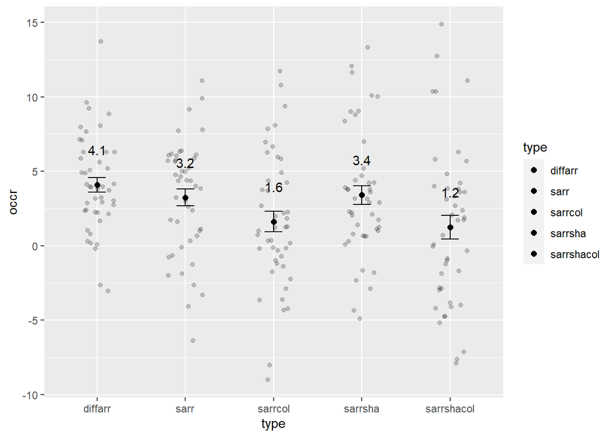

# Mixed models

## Study phase

```
## [1] "Correct categorizations in the second phase"
```

```
##          type   V1
## 1:    diffarr 16.6
## 2:  prototype  0.0
## 3:       sarr  7.1
## 4: sarrshacol  3.0
## 5:    sarrsha  4.3
## 6:    sarrcol  3.2
```

```
## Generalized linear mixed model fit by maximum likelihood (Laplace
##   Approximation) [glmerMod]
##  Family: binomial  ( logit )
## Formula: st_corr ~ difference_from_fams * response_time + (1 | workerId)
##    Data: stlmm
##
##      AIC      BIC   logLik deviance df.resid
##   3183.9   3214.1  -1587.0   3173.9     3070
##
## Scaled residuals:
##     Min      1Q  Median      3Q     Max
## -5.1831 -0.6590  0.4060  0.5763  1.9769
##
## Random effects:
##  Groups   Name        Variance Std.Dev.
##  workerId (Intercept) 0.3363   0.5799
## Number of obs: 3075, groups:  workerId, 41
##
## Fixed effects:
##                                      Estimate Std. Error z value Pr(>|z|)
## (Intercept)                         2.667e+00  1.653e-01  16.136  < 2e-16 ***
## difference_from_fams                9.239e-02  1.548e-02   5.967 2.42e-09 ***
## response_time                      -1.115e-03  7.489e-05 -14.889  < 2e-16 ***
## difference_from_fams:response_time -2.422e-05  8.625e-06  -2.809  0.00498 **
## ---
## Signif. codes:  0 '***' 0.001 '**' 0.01 '*' 0.05 '.' 0.1 ' ' 1
##
## Correlation of Fixed Effects:
##             (Intr) dffr__ rspns_
## dffrnc_frm_ -0.243
## response_tm -0.760  0.192
## dffrnc_f_:_  0.185 -0.796 -0.294
## fit warnings:
## Some predictor variables are on very different scales: consider rescaling
## convergence code: 0
## Model failed to converge with max|grad| = 6.36807 (tol = 0.002, component 1)
## Model is nearly unidentifiable: very large eigenvalue
##  - Rescale variables?
## Model is nearly unidentifiable: large eigenvalue ratio
##  - Rescale variables?
```

```
## Package `effects` is not available, but needed for `ggeffect()`. Either install package `effects`, or use `ggpredict()`. Calling `ggpredict()` now.FALSE
```

```
## Data were 'prettified'. Consider using `terms="response_time [all]"` to get smooth plots.
```

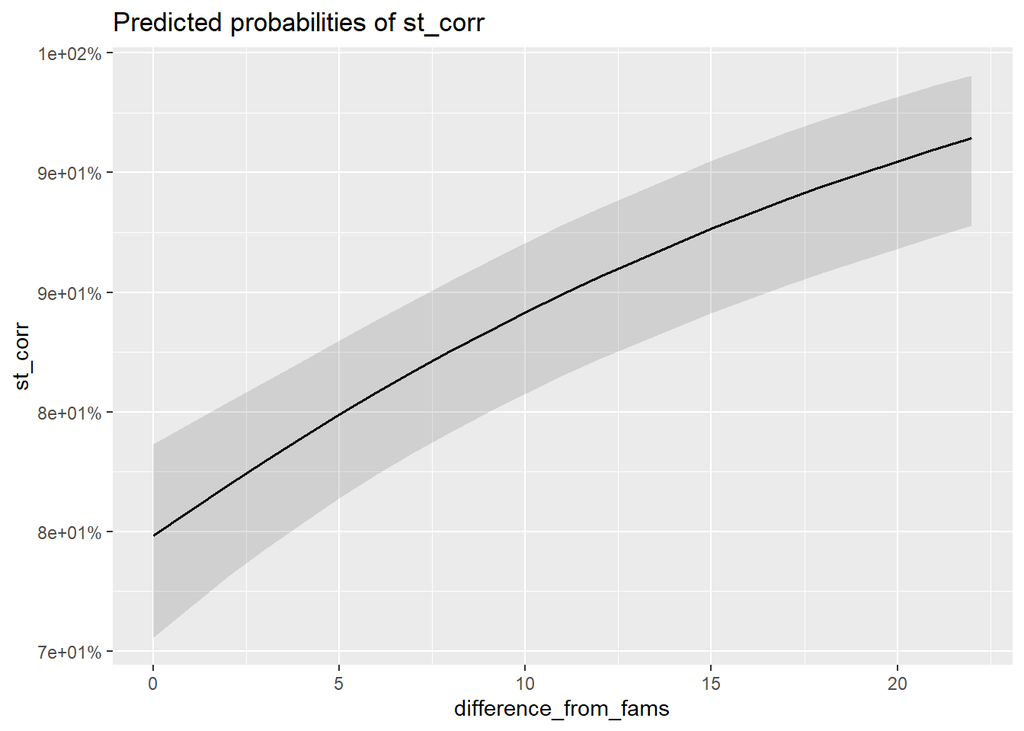

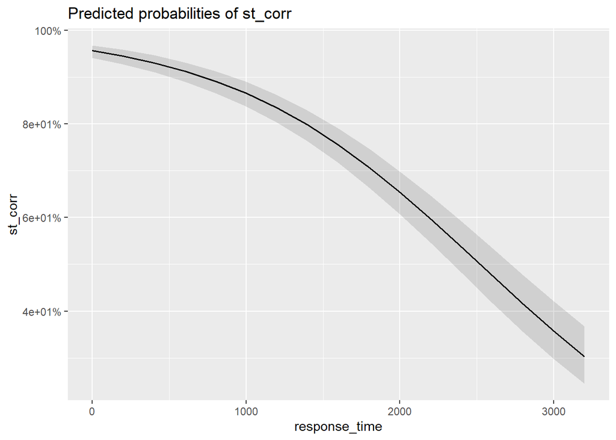

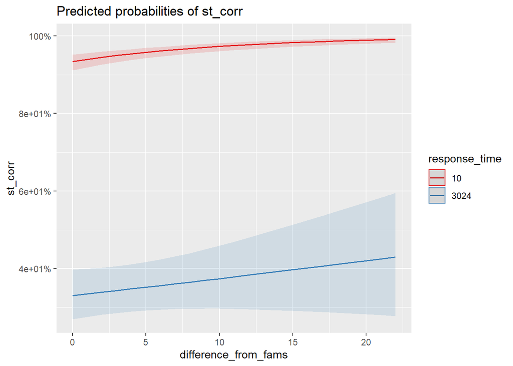

|  | st_corr |  |  |  |
| --- | --- | --- | --- | --- |
| Predictors | Log-Odds | std. Error | CI | p |
| (Intercept) | 2.67 | 0.17 | 2.34 – 2.99 | **<0.001** |
| difference_from_fams | 0.09 | 0.02 | 0.06 – 0.12 | **<0.001** |
| response_time | -0.00 | 0.00 | -0.00 – -0.00 | **<0.001** |
| difference_from_fams * response_time | -0.00 | 0.00 | -0.00 – -0.00 | **0.005** |
| Random Effects |  |  |  |  |
| σ<sup>2</sup> | 3.29 |  |  |  |
| τ<sub>00</sub> <sub>workerId</sub> | 0.34 |  |  |  |
| ICC | 0.09 |  |  |  |
| N <sub>workerId</sub> | 41 |  |  |  |
| Observations | 3075 |  |  |  |
| Marginal R<sup>2</sup> / Conditional R<sup>2</sup> | 0.181 / 0.257 |  |  |  |
| AIC | 3183.934 |  |  |  |

```
## Linear mixed model fit by REML. t-tests use Satterthwaite's method [
## lmerModLmerTest]
## Formula: response_time ~ difference_from_fams * total_responses + (1 |
##     workerId)
##    Data: stlmm
##
## REML criterion at convergence: 48106.1
##
## Scaled residuals:
##     Min      1Q  Median      3Q     Max
## -2.3096 -0.7283 -0.2122  0.5563  3.5033
##
## Random effects:
##  Groups   Name        Variance Std.Dev.
##  workerId (Intercept)  81277   285.1
##  Residual             352292   593.5
## Number of obs: 3075, groups:  workerId, 41
##
## Fixed effects:
##                                       Estimate Std. Error        df t value
## (Intercept)                          1775.3780    53.4093   73.8944  33.241
## difference_from_fams                    5.0500     3.6612 3031.0007   1.379
## total_responses                        -3.8674     0.6492 3031.0252  -5.957
## difference_from_fams:total_responses   -0.4371     0.0897 3031.0001  -4.873
##                                      Pr(>|t|)
## (Intercept)                           < 2e-16 ***
## difference_from_fams                    0.168
## total_responses                      2.86e-09 ***
## difference_from_fams:total_responses 1.15e-06 ***
## ---
## Signif. codes:  0 '***' 0.001 '**' 0.01 '*' 0.05 '.' 0.1 ' ' 1
##
## Correlation of Fixed Effects:
##             (Intr) dffr__ ttl_rs
## dffrnc_frm_ -0.374
## totl_rspnss -0.486  0.603
## dffrnc_f_:_  0.298 -0.840 -0.637
```

```
## Package `effects` is not available, but needed for `ggeffect()`. Either install package `effects`, or use `ggpredict()`. Calling `ggpredict()` now.FALSE
```

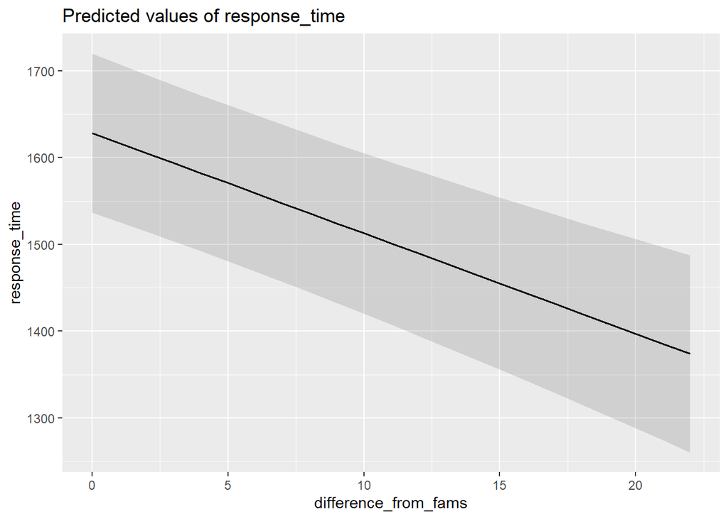

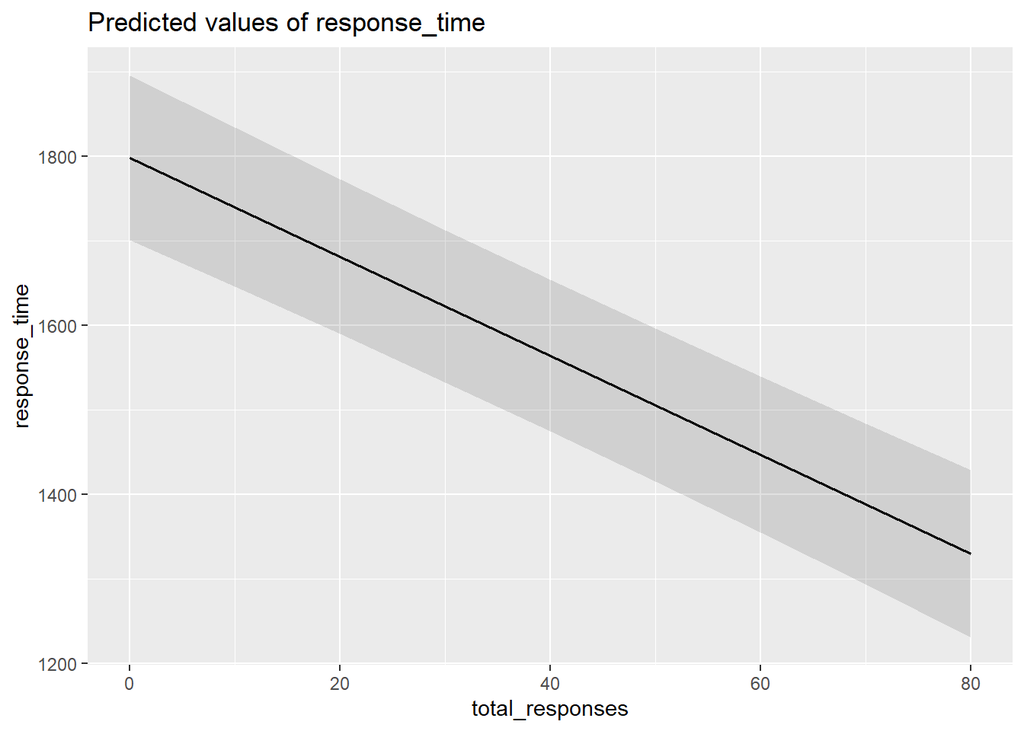

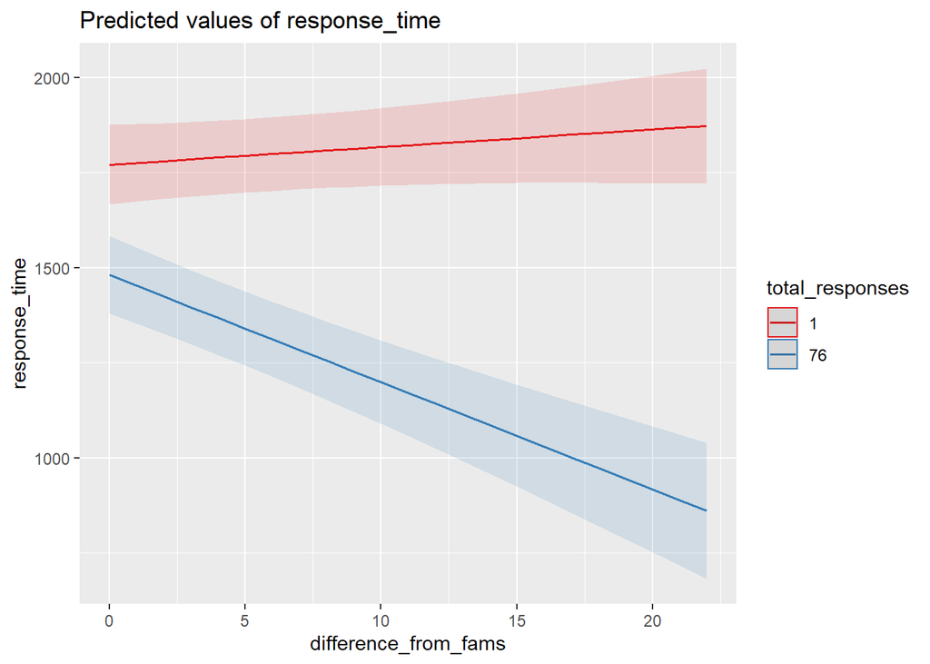

## Test phase

Logistic mixed regression for the test phase. Does difference from prototypes or familiarity/novelty have an effect on correct categorization in the test phase?

```
## [1] "The mean difference by category"
```

```
##          type    V1
## 1:    sarrsha  4.25
## 2: sarrshacol  3.40
## 3:       sarr  7.30
## 4:    diffarr 16.60
## 5:    sarrcol  3.25
```

```
## Generalized linear mixed model fit by maximum likelihood (Laplace
##   Approximation) [glmerMod]
##  Family: binomial  ( logit )
## Formula: correct_response ~ difference_from_fams + (1 | workerId)
##    Data: tdlmm
##
##      AIC      BIC   logLik deviance df.resid
##   5667.7   5686.7  -2830.9   5661.7     4097
##
## Scaled residuals:
##     Min      1Q  Median      3Q     Max
## -1.3062 -1.0279  0.8329  0.9599  1.0960
##
## Random effects:
##  Groups   Name        Variance Std.Dev.
##  workerId (Intercept) 0.01997  0.1413
## Number of obs: 4100, groups:  workerId, 41
##
## Fixed effects:
##                       Estimate Std. Error z value Pr(>|z|)
## (Intercept)          -0.045940   0.056046  -0.820  0.41240
## difference_from_fams  0.019194   0.005907   3.249  0.00116 **
## ---
## Signif. codes:  0 '***' 0.001 '**' 0.01 '*' 0.05 '.' 0.1 ' ' 1
##
## Correlation of Fixed Effects:
##             (Intr)
## dffrnc_frm_ -0.729
```

```
## Package `effects` is not available, but needed for `ggeffect()`. Either install package `effects`, or use `ggpredict()`. Calling `ggpredict()` now.FALSE
```

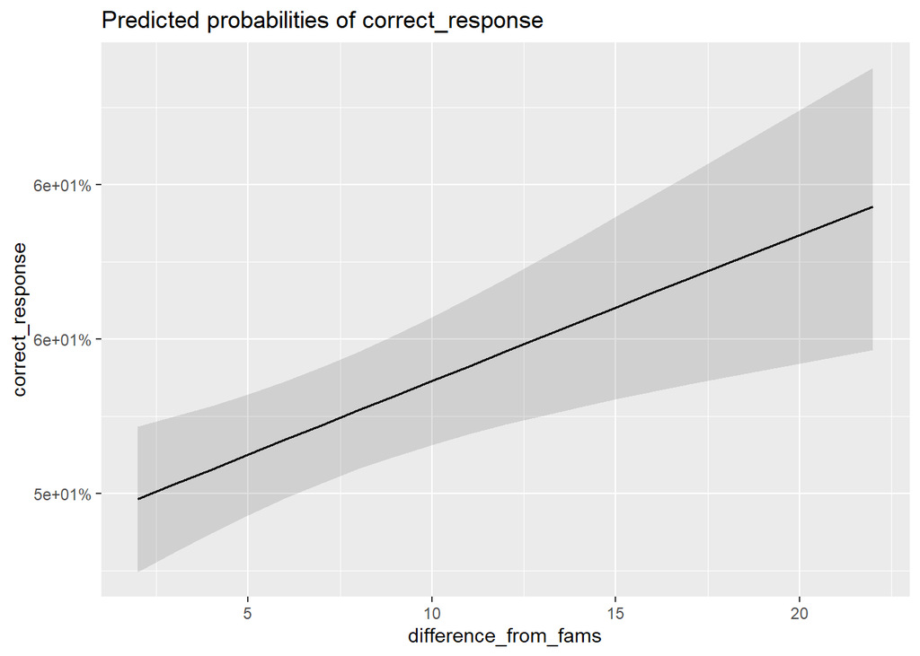

```
## Generalized linear mixed model fit by maximum likelihood (Laplace
##   Approximation) [glmerMod]
##  Family: binomial  ( logit )
## Formula: correct_response ~ difference_from_fams * trial_quality + (1 |
##     workerId) + (1 | difference_from_fams)
##    Data: tdlmm
##
##      AIC      BIC   logLik deviance df.resid
##   5400.9   5438.8  -2694.4   5388.9     4094
##
## Scaled residuals:
##     Min      1Q  Median      3Q     Max
## -3.2065 -0.9790  0.4168  0.9572  1.8956
##
## Random effects:
##  Groups               Name        Variance Std.Dev.
##  workerId             (Intercept) 0.026158 0.16173
##  difference_from_fams (Intercept) 0.005547 0.07448
## Number of obs: 4100, groups:  workerId, 41; difference_from_fams, 18
##
## Fixed effects:
##                                        Estimate Std. Error z value Pr(>|z|)
## (Intercept)                            0.160999   0.092159   1.747   0.0806 .
## difference_from_fams                  -0.057657   0.009699  -5.945 2.77e-09 ***
## trial_qualitynew                      -0.585736   0.110692  -5.292 1.21e-07 ***
## difference_from_fams:trial_qualitynew  0.177397   0.014178  12.512  < 2e-16 ***
## ---
## Signif. codes:  0 '***' 0.001 '**' 0.01 '*' 0.05 '.' 0.1 ' ' 1
##
## Correlation of Fixed Effects:
##             (Intr) dffr__ trl_ql
## dffrnc_frm_ -0.772
## tril_qltynw -0.508  0.468
## dffrnc_f_:_  0.374 -0.566 -0.803
```

```
## Package `effects` is not available, but needed for `ggeffect()`. Either install package `effects`, or use `ggpredict()`. Calling `ggpredict()` now.FALSE
```

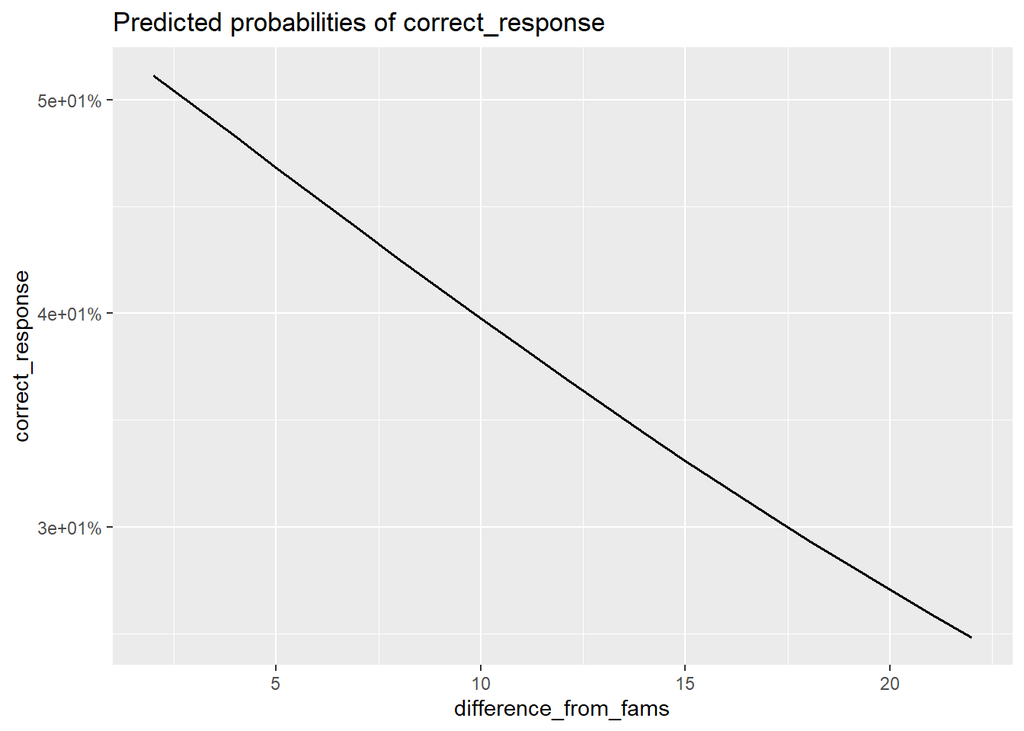

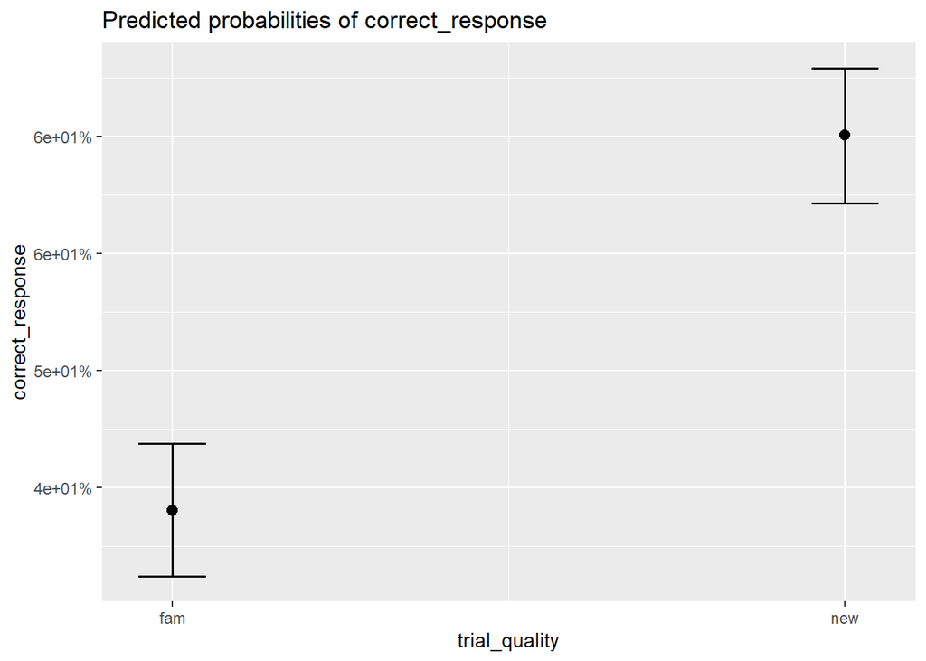

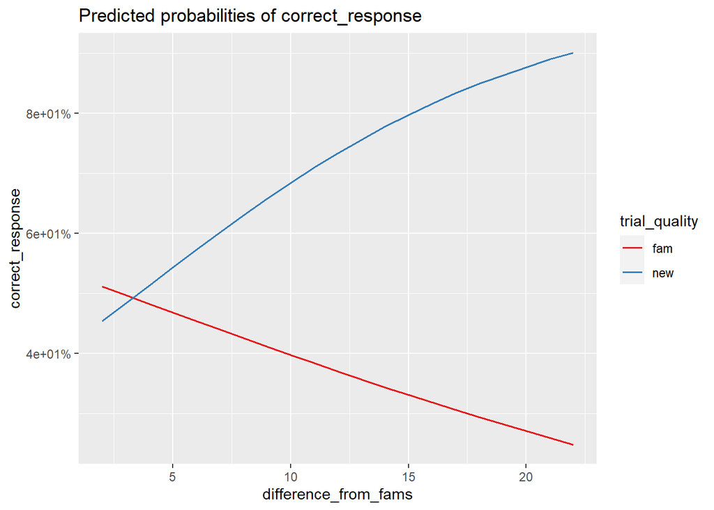

|  | correct_response |  |  |  | correct_response |  |  |  |
| --- | --- | --- | --- | --- | --- | --- | --- | --- |
| Predictors | Log-Odds | std. Error | CI | p | Log-Odds | std. Error | CI | p |
| (Intercept) | 0.16 | 0.09 | -0.02 – 0.34 | 0.081 | -0.05 | 0.06 | -0.16 – 0.06 | 0.412 |
| difference_from_fams | -0.06 | 0.01 | -0.08 – -0.04 | **<0.001** | 0.02 | 0.01 | 0.01 – 0.03 | **0.001** |
| trial_quality [new] | -0.59 | 0.11 | -0.80 – -0.37 | **<0.001** |  |  |  |  |
| difference_from_fams * trial_quality [new] | 0.18 | 0.01 | 0.15 – 0.21 | **<0.001** |  |  |  |  |
| Random Effects |  |  |  |  |  |  |  |  |
| σ<sup>2</sup> | 3.29 |  |  |  | 3.29 |  |  |  |
| τ<sub>00</sub> | 0.03 <sub>workerId</sub> |  |  |  | 0.02 <sub>workerId</sub> |  |  |  |
|  | 0.01 <sub>difference_from_fams</sub> |  |  |  |  |  |  |  |
| ICC | 0.01 |  |  |  | 0.01 |  |  |  |
| N | 41 <sub>workerId</sub> |  |  |  | 41 <sub>workerId</sub> |  |  |  |
|  | 18 <sub>difference_from_fams</sub> |  |  |  |  |  |  |  |
| Observations | 4100 |  |  |  | 4100 |  |  |  |
| Marginal R<sup>2</sup> / Conditional R<sup>2</sup> | 0.097 / 0.106 |  |  |  | 0.003 / 0.009 |  |  |  |
| AIC | 5400.919 |  |  |  | 5667.719 |  |  |  |

Another logistic mixed regression is used to see if phase two variables have an effect in phase three.

```
## Generalized linear mixed model fit by maximum likelihood (Laplace
##   Approximation) [glmerMod]
##  Family: binomial  ( logit )
## Formula: correct_response ~ difference_from_fams * study_rt * study_cr +
##     (1 | workerId)
##    Data: t2lmm
##
##      AIC      BIC   logLik deviance df.resid
##   2671.5   2722.1  -1326.7   2653.5     2041
##
## Scaled residuals:
##     Min      1Q  Median      3Q     Max
## -2.4045 -0.8309 -0.5597  0.9791  2.4745
##
## Random effects:
##  Groups   Name        Variance Std.Dev.
##  workerId (Intercept) 0.258    0.5079
## Number of obs: 2050, groups:  workerId, 41
##
## Fixed effects:
##                                          Estimate Std. Error z value Pr(>|z|)
## (Intercept)                             5.392e-01  3.000e-01   1.798 0.072233
## difference_from_fams                   -3.484e-02  2.974e-02  -1.172 0.241365
## study_rt                                2.446e-04  1.238e-04   1.976 0.048100
## study_cr                               -1.233e+00  3.340e-01  -3.690 0.000224
## difference_from_fams:study_rt          -4.913e-05  1.016e-05  -4.836 1.33e-06
## difference_from_fams:study_cr           3.494e-02  2.962e-02   1.180 0.238145
## study_rt:study_cr                       1.497e-04  1.602e-04   0.934 0.350137
## difference_from_fams:study_rt:study_cr  2.117e-05  1.066e-05   1.986 0.047030
##
## (Intercept)                            .
## difference_from_fams
## study_rt                               *
## study_cr                               ***
## difference_from_fams:study_rt          ***
## difference_from_fams:study_cr
## study_rt:study_cr
## difference_from_fams:study_rt:study_cr *
## ---
## Signif. codes:  0 '***' 0.001 '**' 0.01 '*' 0.05 '.' 0.1 ' ' 1
```

[output cut: 11 more lines]

```
## dffrnc_frm_
## study_rt
## study_cr
## dffrnc_frm_fms:stdy_r
## dffrnc_frm_fms:stdy_c
## stdy_rt:st_            0.154
## dffrn__:_:_           -0.430                -0.333
## fit warnings:
## Some predictor variables are on very different scales: consider rescaling
## convergence code: 0
## Model failed to converge with max|grad| = 23.7174 (tol = 0.002, component 1)
## Model is nearly unidentifiable: very large eigenvalue
##  - Rescale variables?
## Model is nearly unidentifiable: large eigenvalue ratio
##  - Rescale variables?
```

```
## Package `effects` is not available, but needed for `ggeffect()`. Either install package `effects`, or use `ggpredict()`. Calling `ggpredict()` now.FALSE
```

```
## Data were 'prettified'. Consider using `terms="study_rt [all]"` to get smooth plots.
```

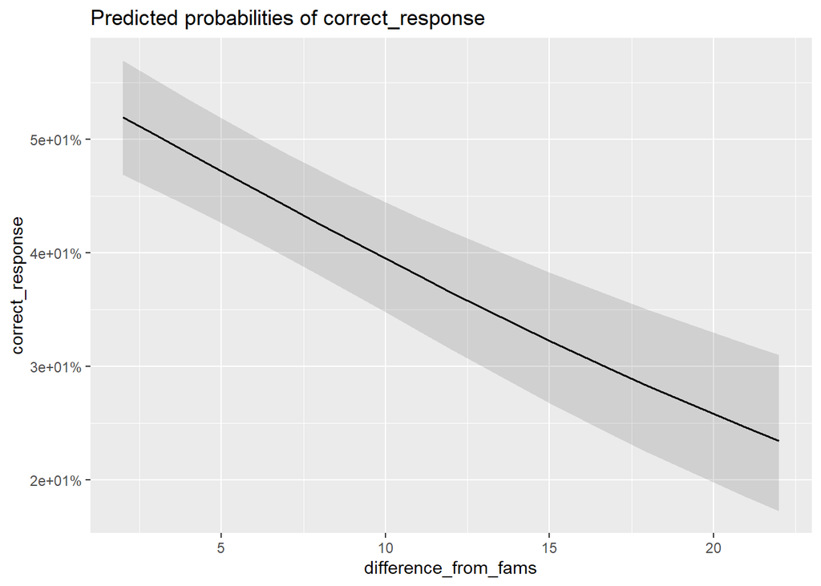

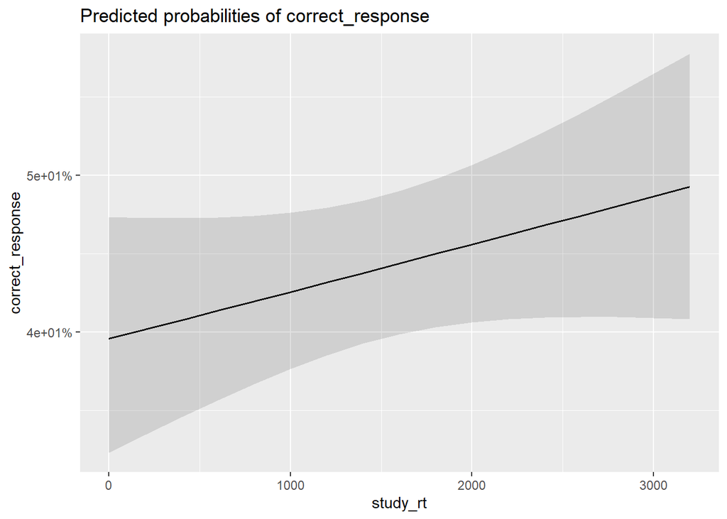

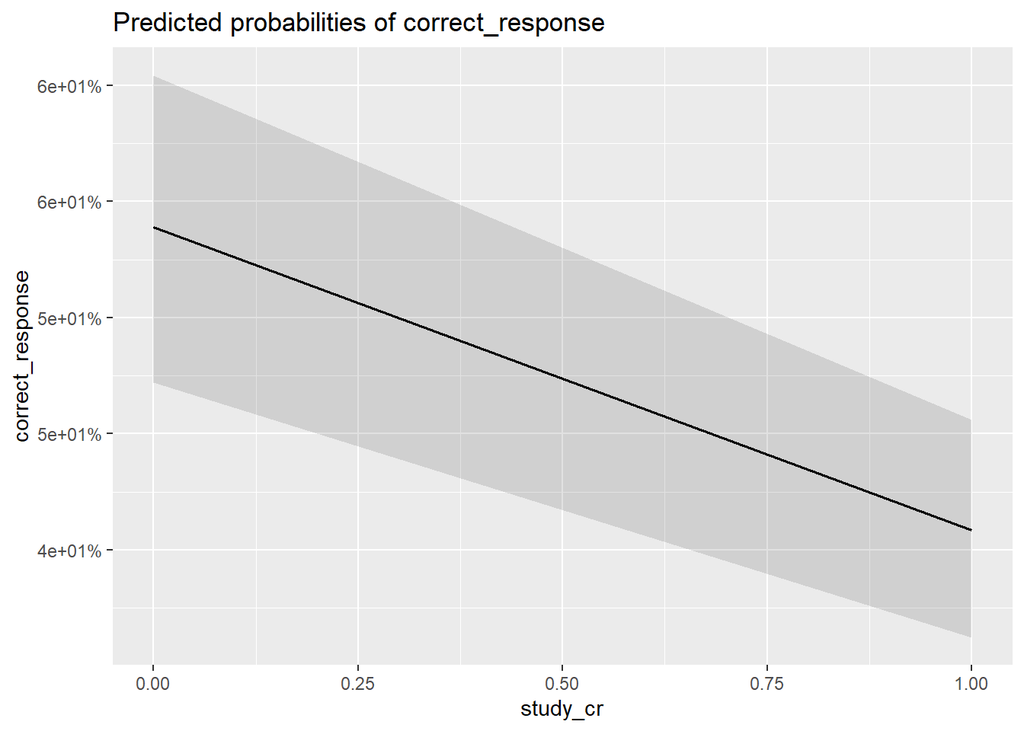

```
## Data were 'prettified'. Consider using `terms="study_rt [all]"` to get smooth plots.
```

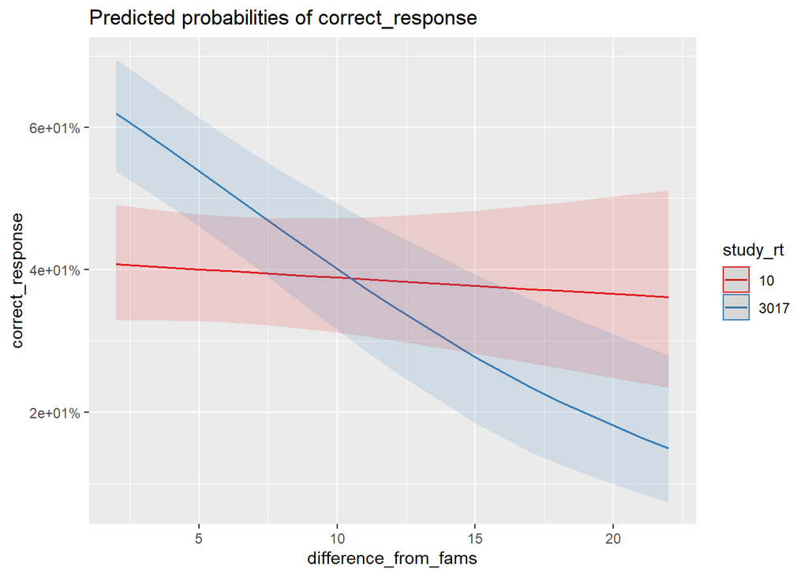

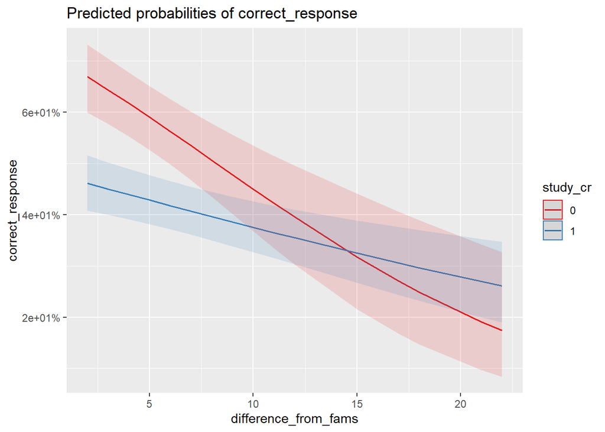

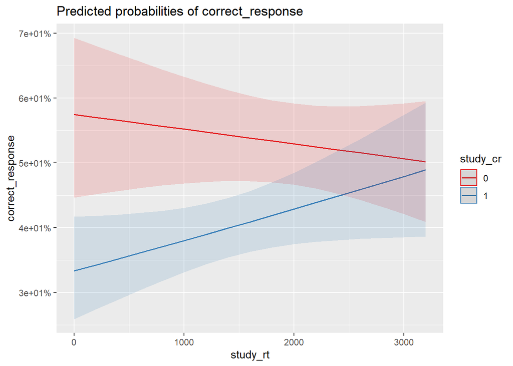

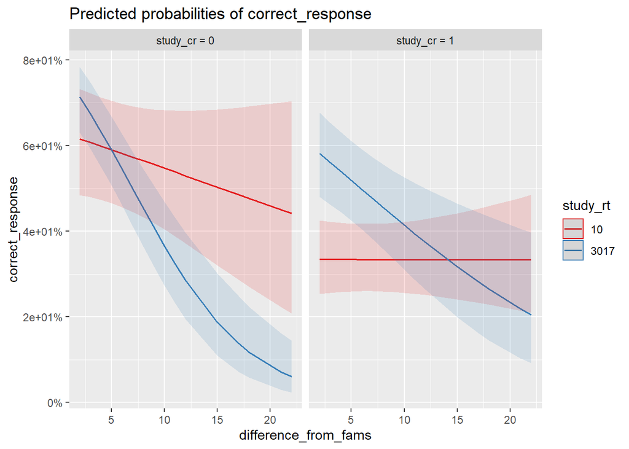

```
## Generalized linear mixed model fit by maximum likelihood (Laplace
##   Approximation) [glmerMod]
##  Family: binomial  ( logit )
## Formula: correct_response ~ difference_from_fams * study_rt * study_cr +
##     (1 | workerId) + (1 | difference_from_fams)
##    Data: t2lmm
##
##      AIC      BIC   logLik deviance df.resid
##   2669.1   2725.3  -1324.5   2649.1     2040
##
## Scaled residuals:
##     Min      1Q  Median      3Q     Max
## -2.4946 -0.8183 -0.5540  0.9672  2.6048
##
## Random effects:
##  Groups               Name        Variance Std.Dev.
##  workerId             (Intercept) 0.26581  0.5156
##  difference_from_fams (Intercept) 0.03564  0.1888
## Number of obs: 2050, groups:  workerId, 41; difference_from_fams, 16
##
## Fixed effects:
##                                          Estimate Std. Error z value Pr(>|z|)
## (Intercept)                             4.031e-01  4.276e-01   0.943   0.3458
## difference_from_fams                   -2.773e-02  5.953e-02  -0.466   0.6413
## study_rt                                2.530e-04  1.926e-04   1.314   0.1890
## study_cr                               -1.190e+00  4.762e-01  -2.498   0.0125 *
## difference_from_fams:study_rt          -4.859e-05  2.828e-05  -1.718   0.0857 .
## difference_from_fams:study_cr           3.293e-02  6.500e-02   0.507   0.6124
## study_rt:study_cr                       1.408e-04  2.517e-04   0.559   0.5759
## difference_from_fams:study_rt:study_cr  2.085e-05  3.375e-05   0.618   0.5366
## ---
## Signif. codes:  0 '***' 0.001 '**' 0.01 '*' 0.05 '.' 0.1 ' ' 1
##
## Correlation of Fixed Effects:
##                       (Intr) dffr__ stdy_r stdy_c dffrnc_frm_fms:stdy_r
## dffrnc_frm_           -0.776
## study_rt              -0.871  0.726
## study_cr              -0.799  0.666  0.767
## dffrnc_frm_fms:stdy_r  0.686 -0.903 -0.803 -0.615
## dffrnc_frm_fms:stdy_c  0.680 -0.896 -0.661 -0.785  0.824
## stdy_rt:st_            0.653 -0.554 -0.745 -0.914  0.609
## dffrn__:_:_           -0.573  0.755  0.668  0.724 -0.833
##                       dffrnc_frm_fms:stdy_c std_:_
## dffrnc_frm_
## study_rt
## study_cr
## dffrnc_frm_fms:stdy_r
## dffrnc_frm_fms:stdy_c
## stdy_rt:st_            0.714
## dffrn__:_:_           -0.909                -0.792
## fit warnings:
## Some predictor variables are on very different scales: consider rescaling
## convergence code: 0
## unable to evaluate scaled gradient
## Model failed to converge: degenerate  Hessian with 1 negative eigenvalues
```

```
## Package `effects` is not available, but needed for `ggeffect()`. Either install package `effects`, or use `ggpredict()`. Calling `ggpredict()` now.FALSE
## Data were 'prettified'. Consider using `terms="study_rt [all]"` to get smooth plots.
```

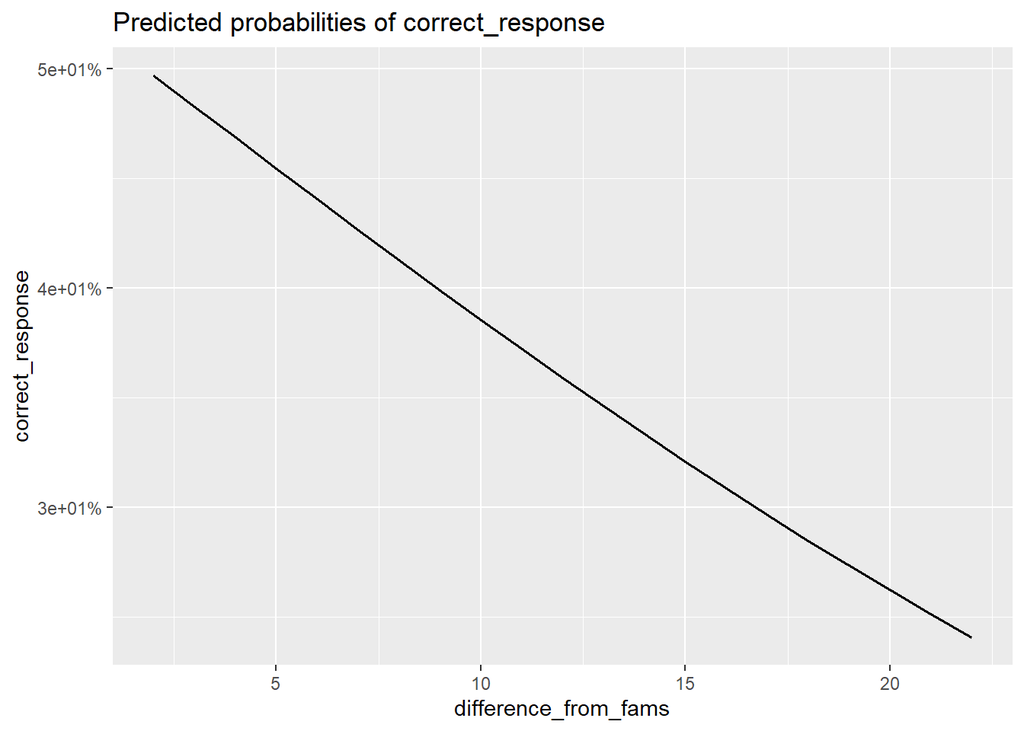

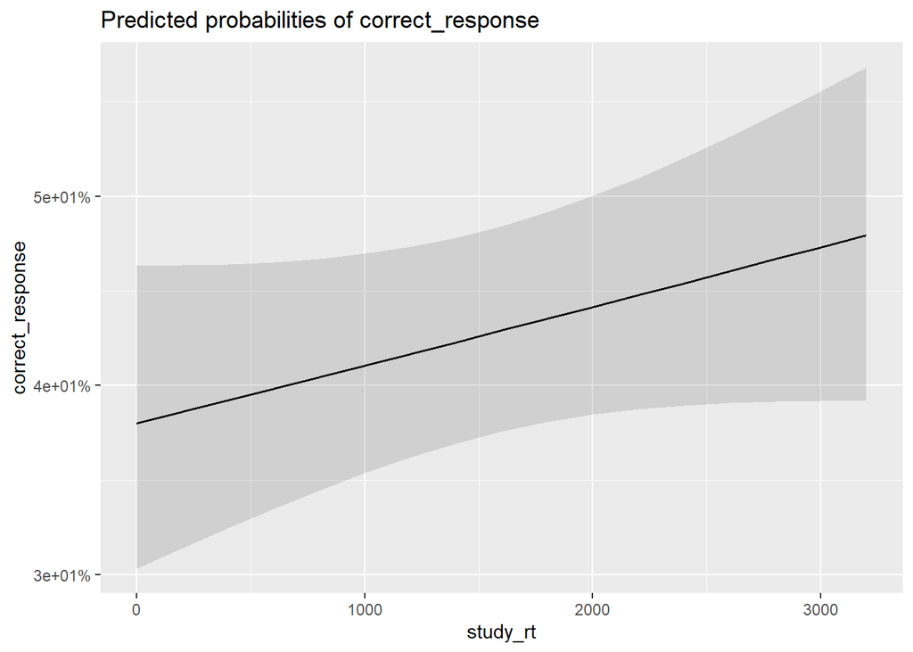

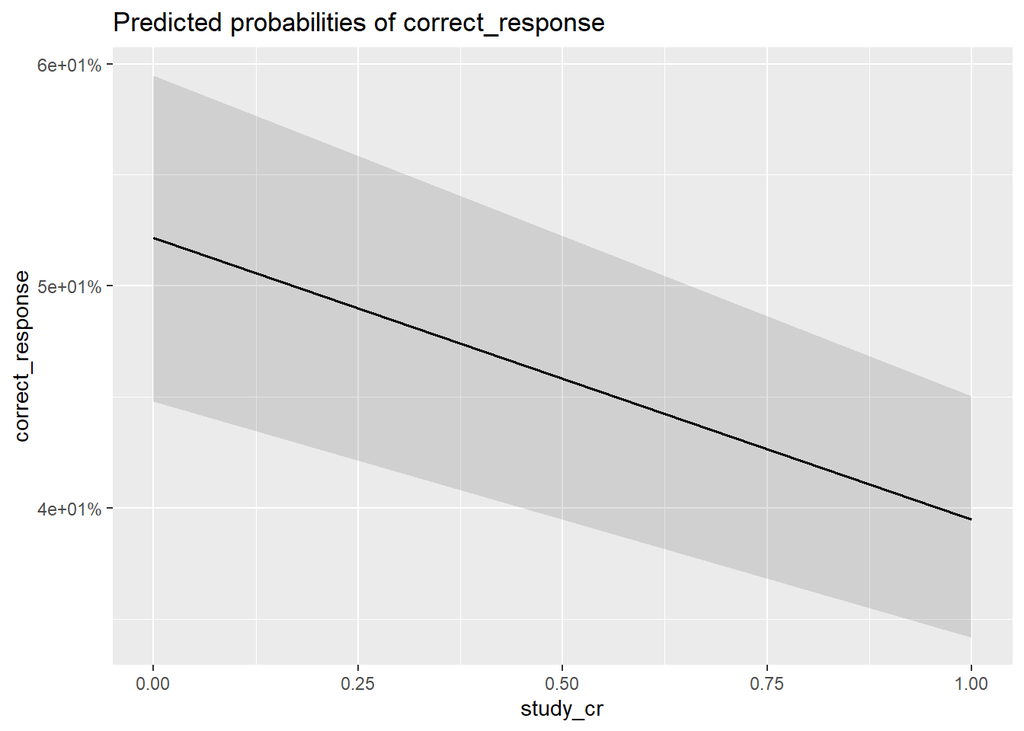

```
## Data were 'prettified'. Consider using `terms="study_rt [all]"` to get smooth plots.
```

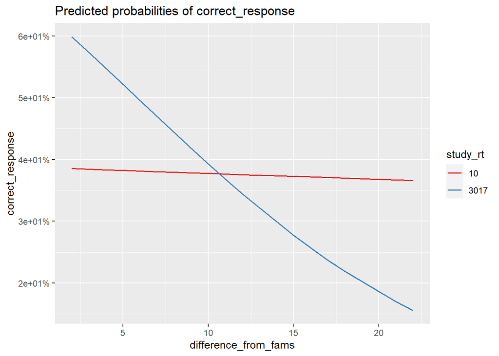